# UPWORK Stock Price Analysis

```python
#input the necessary libraries
```

```python
import pandas as pd
import numpy as np
import matplotlib.pyplot as plt
import seaborn as sns
import os
```

```python
##Loading the Excel files
data= pd.read_csv("UPWK.csv",index_col='Date',parse_dates=True)
```

```python
data.head()
```

| Date | Open | High | Low | Close | Adj Close | Volume |
| --- | --- | --- | --- | --- | --- | --- |
| 2018-10-01 | 23.000000 | 23.490000 | 20.330000 | 20.990000 | 20.990000 | 10412000 |
| 2018-10-08 | 20.950001 | 20.950001 | 18.790001 | 19.209999 | 19.209999 | 4706400 |
| 2018-10-15 | 19.299999 | 20.860001 | 19.000000 | 19.440001 | 19.440001 | 1405900 |
| 2018-10-22 | 19.660000 | 20.330000 | 16.700001 | 18.690001 | 18.690001 | 2725800 |
| 2018-10-29 | 19.150000 | 20.740000 | 17.780001 | 20.260000 | 20.260000 | 1786000 |

```python
data.shape
```

```
(220, 6)
```

```python
data.info()
```

```
<class 'pandas.core.frame.DataFrame'>
DatetimeIndex: 220 entries, 2018-10-01 to 2022-12-12
Data columns (total 6 columns):
 #   Column     Non-Null Count  Dtype
---  ------     --------------  -----
 0   Open       220 non-null    float64
 1   High       220 non-null    float64
 2   Low        220 non-null    float64
 3   Close      220 non-null    float64
 4   Adj Close  220 non-null    float64
 5   Volume     220 non-null    int64
dtypes: float64(5), int64(1)
memory usage: 12.0 KB
```

```python
data.isnull().sum()
```

```
Open         0
High         0
Low          0
Close        0
Adj Close    0
Volume       0
dtype: int64
```

```python
data.describe()
```

|  | Open | High | Low | Close | Adj Close | Volume |
| --- | --- | --- | --- | --- | --- | --- |
| count | 220.000000 | 220.000000 | 220.000000 | 220.000000 | 220.000000 | 2.200000e+02 |
| mean | 24.175227 | 25.834091 | 22.424727 | 24.141091 | 24.141091 | 7.668269e+06 |
| std | 14.010102 | 15.064436 | 12.814484 | 14.002850 | 14.002850 | 5.110529e+06 |
| min | 5.850000 | 6.830000 | 5.140000 | 5.400000 | 5.400000 | 7.018000e+05 |
| 25% | 14.515000 | 15.195000 | 13.570000 | 14.385000 | 14.385000 | 4.649825e+06 |
| 50% | 19.005000 | 20.175000 | 17.865000 | 18.900001 | 18.900001 | 6.621950e+06 |
| 75% | 34.112501 | 36.112500 | 31.992500 | 34.167500 | 34.167500 | 9.640350e+06 |
| max | 59.750000 | 64.489998 | 55.869999 | 59.209999 | 59.209999 | 3.800490e+07 |

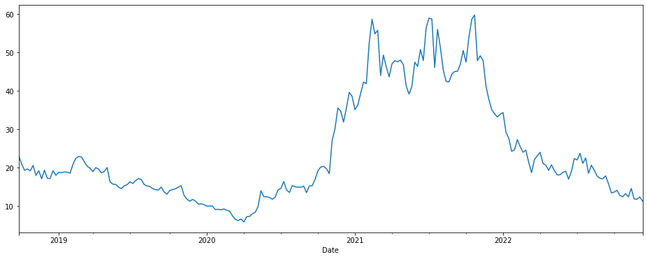

```python
data['Open'].plot(figsize=(16,6))
```

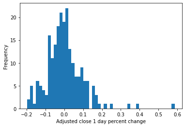

```python
data['Close'].pct_change().plot.hist(bins=50)
plt.xlabel("Adjusted close 1 day percent change")
plt.show()
```

```python
import datetime as dt
import pandas as pd
import numpy as np
from numpy import arange
import matplotlib.pyplot as plt
from pandas import read_csv
from sklearn import metrics
from sklearn.model_selection import train_test_split
from sklearn.ensemble import RandomForestRegressor
from sklearn.preprocessing import StandardScaler
from sklearn.model_selection import RandomizedSearchCV
```

```python
data.head()
```

| Date | Open | High | Low | Close | Adj Close | Volume |
| --- | --- | --- | --- | --- | --- | --- |
| 2018-10-01 | 23.000000 | 23.490000 | 20.330000 | 20.990000 | 20.990000 | 10412000 |
| 2018-10-08 | 20.950001 | 20.950001 | 18.790001 | 19.209999 | 19.209999 | 4706400 |
| 2018-10-15 | 19.299999 | 20.860001 | 19.000000 | 19.440001 | 19.440001 | 1405900 |
| 2018-10-22 | 19.660000 | 20.330000 | 16.700001 | 18.690001 | 18.690001 | 2725800 |
| 2018-10-29 | 19.150000 | 20.740000 | 17.780001 | 20.260000 | 20.260000 | 1786000 |

```python
x = data.iloc[:, 0:5].values
y = data.iloc[:, 4].values
```

# x is holding values for the open, high, low, close and adj close columns. yis holding values for the adj-close column. The other columns, including that of volume, were not selected for the process because they will not be needed. Five features were used.

```python
x_train, x_test, y_train, y_test = train_test_split(x, y, test_size=0.26,  random_state=0)
```

Step 4: Scaling the features

```python
scale = StandardScaler()
x_train = scale.fit_transform(x_train)
x_test = scale.transform(x_test)
```

Step 4: Hyperparemater tuning

For a random forest regression model, the best parameters to consider are:

```
n_estimators — number of trees in the forest
max_depth — maximum depth in a tree
min_samples_split — minimum number of data points before the sample is split
min_samples_leaf — minimum number of leaf nodes that are required to be sampled
bootstrap — sampling for data points, true or false
random_state — generated random numbers for the random forest.
```

```python
model = RandomForestRegressor(n_estimators=500, random_state=42, min_samples_split=2, min_samples_leaf=1, max_depth=10, bootstrap=True)
model.fit(x_train, y_train)
predict = model.predict(x_test)
print(predict)
print(predict.shape)
```

```
[44.57518014  8.39396     9.13176    49.12223875 47.67535948 55.70976017
 10.36874    44.97724013 11.35606    41.70519988 41.99478013 17.64655979
 14.04542167 33.91017952 18.06541993 18.5806802  19.38474    14.92472
 20.01751988  7.73218    14.80128    17.98359986 53.88010026 10.24646
 15.4291     45.9186005  15.04888    11.32186    18.60867025 20.66166057
 18.8324601  18.98928    46.51844048 16.94900007 55.58336017 55.70976017
 40.32361873 55.70976017 18.61126033 50.32283874 10.00876    15.76904
 12.27227    55.77470016 23.90436023 24.40674054 19.46319186 13.73914
 18.98686001 47.98925948 20.66610063 55.11194005 21.53635999 21.73148005
 15.00364    22.2362404  20.20353937 11.73996   ]
(58,)
```

```python
grid_rf = {
'n_estimators': [20, 50, 100, 500, 1000],
'max_depth': np.arange(1, 15, 1),
'min_samples_split': [2, 10, 9],
'min_samples_leaf': np.arange(1, 15, 2, dtype=int),
'bootstrap': [True, False],
'random_state': [1, 2, 30, 42]
}
rscv = RandomizedSearchCV(estimator=model, param_distributions=grid_rf, cv=3, n_jobs=-1, verbose=2, n_iter=200)
rscv_fit = rscv.fit(x_train, y_train)
best_parameters = rscv_fit.best_params_
print(best_parameters)
```

```
Fitting 3 folds for each of 200 candidates, totalling 600 fits
{'random_state': 42, 'n_estimators': 100, 'min_samples_split': 2, 'min_samples_leaf': 1, 'max_depth': 14, 'bootstrap': True}
```

Statistical metrics and performance evaluation

Root mean square error (RMSE)

```python
print("Mean Absolute Error:", round(metrics.mean_absolute_error(y_test, predict), 4))
print("Mean Squared Error:", round(metrics.mean_squared_error(y_test, predict), 4))
print("Root Mean Squared Error:", round(np.sqrt(metrics.mean_squared_error(y_test, predict)), 4))
print("(R^2) Score:", round(metrics.r2_score(y_test, predict), 4))
print(f'Train Score : {model.score(x_train, y_train) * 100:.2f}% and Test Score : {model.score(x_test, y_test) * 100:.2f}% using Random Tree Regressor.')
errors = abs(predict - y_test)
mape = 100 * (errors / y_test)
accuracy = 100 - np.mean(mape)
print('Accuracy:', round(accuracy, 2), '%.')
```

```
Mean Absolute Error: 0.3377
Mean Squared Error: 0.6117
Root Mean Squared Error: 0.7821
(R^2) Score: 0.9977
Train Score : 99.98% and Test Score : 99.77% using Random Tree Regressor.
Accuracy: 98.98 %.
```

```python
predictions = pd.DataFrame({"Predictions": predict},
index=pd.date_range(start=data.index[-1], periods=len(predict), freq="D"))
predictions.to_csv("Predicted-price-data.csv")
#colllects future days from predicted values
oneyear_df = pd.DataFrame(predictions[:252])
oneyear_df.to_csv("one-year-predictions.csv")
onemonth_df = pd.DataFrame(predictions[:21])
onemonth_df.to_csv("one-month-predictions.csv")
fivedays_df = pd.DataFrame(predictions[:5])
fivedays_df.to_csv("five-days-predictions.csv")
```

```python
predictions
```

|  | Predictions |
| --- | --- |
| 2022-12-12 | 44.575180 |
| 2022-12-13 | 8.393960 |
| 2022-12-14 | 9.131760 |
| 2022-12-15 | 49.122239 |
| 2022-12-16 | 47.675359 |
| 2022-12-17 | 55.709760 |
| 2022-12-18 | 10.368740 |
| 2022-12-19 | 44.977240 |
| 2022-12-20 | 11.356060 |
| 2022-12-21 | 41.705200 |
| 2022-12-22 | 41.994780 |
| 2022-12-23 | 17.646560 |
| 2022-12-24 | 14.045422 |
| 2022-12-25 | 33.910180 |
| 2022-12-26 | 18.065420 |
| 2022-12-27 | 18.580680 |
| 2022-12-28 | 19.384740 |
| 2022-12-29 | 14.924720 |
| 2022-12-30 | 20.017520 |
| 2022-12-31 | 7.732180 |
| 2023-01-01 | 14.801280 |
| 2023-01-02 | 17.983600 |
| 2023-01-03 | 53.880100 |
| 2023-01-04 | 10.246460 |
| 2023-01-05 | 15.429100 |
| 2023-01-06 | 45.918600 |
| 2023-01-07 | 15.048880 |
| 2023-01-08 | 11.321860 |
| 2023-01-09 | 18.608670 |
| 2023-01-10 | 20.661661 |
| 2023-01-11 | 18.832460 |
| 2023-01-12 | 18.989280 |
| 2023-01-13 | 46.518440 |
| 2023-01-14 | 16.949000 |
| 2023-01-15 | 55.583360 |
| 2023-01-16 | 55.709760 |
| 2023-01-17 | 40.323619 |
| 2023-01-18 | 55.709760 |
| 2023-01-19 | 18.611260 |
| 2023-01-20 | 50.322839 |
| 2023-01-21 | 10.008760 |
| 2023-01-22 | 15.769040 |
| 2023-01-23 | 12.272270 |
| 2023-01-24 | 55.774700 |
| 2023-01-25 | 23.904360 |
| 2023-01-26 | 24.406741 |
| 2023-01-27 | 19.463192 |
| 2023-01-28 | 13.739140 |
| 2023-01-29 | 18.986860 |
| 2023-01-30 | 47.989259 |
| 2023-01-31 | 20.666101 |
| 2023-02-01 | 55.111940 |
| 2023-02-02 | 21.536360 |
| 2023-02-03 | 21.731480 |
| 2023-02-04 | 15.003640 |
| 2023-02-05 | 22.236240 |
| 2023-02-06 | 20.203539 |
| 2023-02-07 | 11.739960 |

```python
oneyear_df
```

|  | Predictions |
| --- | --- |
| 2022-12-12 | 44.575180 |
| 2022-12-13 | 8.393960 |
| 2022-12-14 | 9.131760 |
| 2022-12-15 | 49.122239 |
| 2022-12-16 | 47.675359 |
| 2022-12-17 | 55.709760 |
| 2022-12-18 | 10.368740 |
| 2022-12-19 | 44.977240 |
| 2022-12-20 | 11.356060 |
| 2022-12-21 | 41.705200 |
| 2022-12-22 | 41.994780 |
| 2022-12-23 | 17.646560 |
| 2022-12-24 | 14.045422 |
| 2022-12-25 | 33.910180 |
| 2022-12-26 | 18.065420 |
| 2022-12-27 | 18.580680 |
| 2022-12-28 | 19.384740 |
| 2022-12-29 | 14.924720 |
| 2022-12-30 | 20.017520 |
| 2022-12-31 | 7.732180 |
| 2023-01-01 | 14.801280 |
| 2023-01-02 | 17.983600 |
| 2023-01-03 | 53.880100 |
| 2023-01-04 | 10.246460 |
| 2023-01-05 | 15.429100 |
| 2023-01-06 | 45.918600 |
| 2023-01-07 | 15.048880 |
| 2023-01-08 | 11.321860 |
| 2023-01-09 | 18.608670 |
| 2023-01-10 | 20.661661 |
| 2023-01-11 | 18.832460 |
| 2023-01-12 | 18.989280 |
| 2023-01-13 | 46.518440 |
| 2023-01-14 | 16.949000 |
| 2023-01-15 | 55.583360 |
| 2023-01-16 | 55.709760 |
| 2023-01-17 | 40.323619 |
| 2023-01-18 | 55.709760 |
| 2023-01-19 | 18.611260 |
| 2023-01-20 | 50.322839 |
| 2023-01-21 | 10.008760 |
| 2023-01-22 | 15.769040 |
| 2023-01-23 | 12.272270 |
| 2023-01-24 | 55.774700 |
| 2023-01-25 | 23.904360 |
| 2023-01-26 | 24.406741 |
| 2023-01-27 | 19.463192 |
| 2023-01-28 | 13.739140 |
| 2023-01-29 | 18.986860 |
| 2023-01-30 | 47.989259 |
| 2023-01-31 | 20.666101 |
| 2023-02-01 | 55.111940 |
| 2023-02-02 | 21.536360 |
| 2023-02-03 | 21.731480 |
| 2023-02-04 | 15.003640 |
| 2023-02-05 | 22.236240 |
| 2023-02-06 | 20.203539 |
| 2023-02-07 | 11.739960 |

```python
onemonth_df
```

|  | Predictions |
| --- | --- |
| 2022-12-12 | 44.575180 |
| 2022-12-13 | 8.393960 |
| 2022-12-14 | 9.131760 |
| 2022-12-15 | 49.122239 |
| 2022-12-16 | 47.675359 |
| 2022-12-17 | 55.709760 |
| 2022-12-18 | 10.368740 |
| 2022-12-19 | 44.977240 |
| 2022-12-20 | 11.356060 |
| 2022-12-21 | 41.705200 |
| 2022-12-22 | 41.994780 |
| 2022-12-23 | 17.646560 |
| 2022-12-24 | 14.045422 |
| 2022-12-25 | 33.910180 |
| 2022-12-26 | 18.065420 |
| 2022-12-27 | 18.580680 |
| 2022-12-28 | 19.384740 |
| 2022-12-29 | 14.924720 |
| 2022-12-30 | 20.017520 |
| 2022-12-31 | 7.732180 |
| 2023-01-01 | 14.801280 |

```python
fivedays_df
```

|  | Predictions |
| --- | --- |
| 2022-12-12 | 44.575180 |
| 2022-12-13 | 8.393960 |
| 2022-12-14 | 9.131760 |
| 2022-12-15 | 49.122239 |
| 2022-12-16 | 47.675359 |

```
Buy price and date
    Unnamed: 0  Predictions
19  2022-12-31      7.73218
Sell price and date
    Unnamed: 0  Predictions
43  2023-01-24      55.7747
```

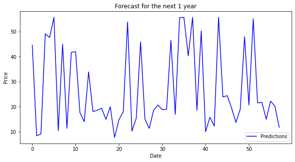

```python
oneyear_df_pred = pd.read_csv("one-year-predictions.csv")
#oneyear_df_pred.set_index("Date", inplace=True)
buy_price = min(oneyear_df_pred["Predictions"])
sell_price = max(oneyear_df_pred["Predictions"])
oneyear_buy = oneyear_df_pred.loc[oneyear_df_pred["Predictions"] == buy_price]
oneyear_sell = oneyear_df_pred.loc[oneyear_df_pred["Predictions"] == sell_price]
print("Buy price and date")
print(oneyear_buy)
print("Sell price and date")
print(oneyear_sell)
oneyear_df_pred["Predictions"].plot(figsize=(10, 5), title="Forecast for the next 1 year", color="blue")
plt.xlabel("Date")
plt.ylabel("Price")
plt.legend()
plt.show()
```

One month prediction:

```
Buy price and date
    Unnamed: 0  Predictions
19  2022-12-31      7.73218
Sell price and date
   Unnamed: 0  Predictions
5  2022-12-17     55.70976
```

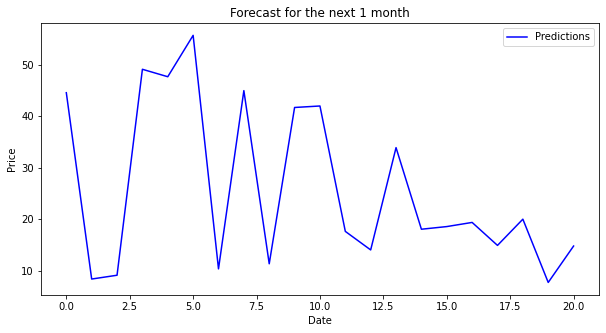

```python
onemonth_df_pred = pd.read_csv("one-month-predictions.csv")
#onemonth_df_pred.set_index("Date", inplace=True)
buy_price = min(onemonth_df_pred["Predictions"])
sell_price = max(onemonth_df_pred["Predictions"])
onemonth_buy = onemonth_df_pred.loc[onemonth_df_pred["Predictions"] == buy_price]
onemonth_sell = onemonth_df_pred.loc[onemonth_df_pred["Predictions"] == sell_price]
print("Buy price and date")
print(onemonth_buy)
print("Sell price and date")
print(onemonth_sell)
onemonth_df_pred["Predictions"].plot(figsize=(10, 5), title="Forecast for the next 1 month", color="blue")
plt.xlabel("Date")
plt.ylabel("Price")
plt.legend()
plt.show()
```

Five days prediction :

```
Buy price and date
   Unnamed: 0  Predictions
1  2022-12-13      8.39396
Sell price and date
   Unnamed: 0  Predictions
3  2022-12-15    49.122239
```

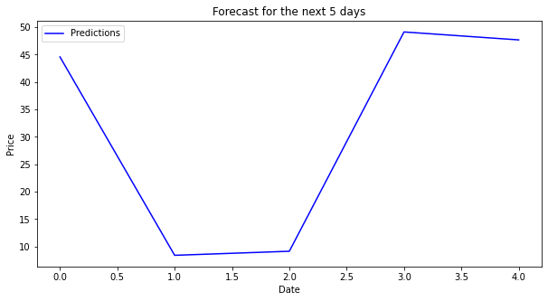

```python
fivedays_df_pred = pd.read_csv("five-days-predictions.csv")
#fivedays_df_pred.set_index("Date", inplace=True)
buy_price = min(fivedays_df_pred["Predictions"])
sell_price = max(fivedays_df_pred["Predictions"])
fivedays_buy = fivedays_df_pred.loc[fivedays_df_pred["Predictions"] == buy_price]
fivedays_sell = fivedays_df_pred.loc[fivedays_df_pred["Predictions"] == sell_price]
print("Buy price and date")
print(fivedays_buy)
print("Sell price and date")
print(fivedays_sell)
fivedays_df_pred["Predictions"].plot(figsize=(10, 5), title="Forecast for the next 5 days", color="blue")
plt.xlabel("Date")
plt.ylabel("Price")
plt.legend()
plt.show()
```

Conclusion

There are different approaches to solving these problems. Their performance can differ from mathematical analysis for prediction to sentiment analysis, financial news articles, and expert reviews.Overall, random forest is mostly fast, simple, and flexible, but not without some limitations.

# STOCK MARKET PREDICTIONS USING LSTM

```python
##Loading the Excel files
df1= pd.read_csv("UPWK.csv",index_col='Date',parse_dates=True)
```

```python
df1.head()
```

| Date | Open | High | Low | Close | Adj Close | Volume |
| --- | --- | --- | --- | --- | --- | --- |
| 2018-10-01 | 23.000000 | 23.490000 | 20.330000 | 20.990000 | 20.990000 | 10412000 |
| 2018-10-08 | 20.950001 | 20.950001 | 18.790001 | 19.209999 | 19.209999 | 4706400 |
| 2018-10-15 | 19.299999 | 20.860001 | 19.000000 | 19.440001 | 19.440001 | 1405900 |
| 2018-10-22 | 19.660000 | 20.330000 | 16.700001 | 18.690001 | 18.690001 | 2725800 |
| 2018-10-29 | 19.150000 | 20.740000 | 17.780001 | 20.260000 | 20.260000 | 1786000 |

```python
df1.shape
```

```
(220, 6)
```

```python
df1=df1['Close']
```

```python
df1
```

```
Date
2018-10-01    20.990000
2018-10-08    19.209999
2018-10-15    19.440001
2018-10-22    18.690001
2018-10-29    20.260000
                ...
2022-11-14    12.160000
2022-11-21    11.790000
2022-11-28    12.380000
2022-12-05    11.250000
2022-12-12    11.460000
Name: Close, Length: 220, dtype: float64
```

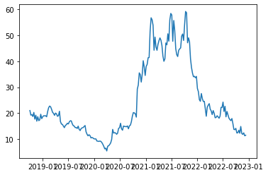

```python
import matplotlib.pyplot as plt
plt.plot(df1)
```

```python
#Importing Keras Libraries and Packages
from keras.models import Sequential
from keras.layers import Dense
from keras.layers import LSTM
from keras.layers import Dropout
```

```python
from sklearn.preprocessing import MinMaxScaler
scaler=MinMaxScaler(feature_range=(0,1))
df1=scaler.fit_transform(np.array(df1).reshape(-1,1))
```

```python
df1
```

```
array([[0.28972311],
       [0.25664373],
       [0.26091807],
       [0.24698014],
       [0.27615685],
       [0.22821037],
       [0.25645793],
       [0.21352907],
       [0.24586507],
       [0.21724587],
       [0.22282102],
       [0.2631481 ],
       [0.2315555 ],
       [0.24512173],
       [0.25255529],
       [0.25162612],
       [0.25236945],
       [0.24493589],
       [0.28191786],
       [0.30960787],
       [0.32187325],
       [0.31685563],
       [0.29882922],
       [0.27708603],
       [0.26946665],
       [0.25534286],
       [0.27151088],
       [0.26593569],
       [0.24828099],
       [0.25311281],
       [0.28433379],
       [0.21092734],
       [0.19290095],
       [0.19048504],
       [0.17803383],
       [0.16706932],
       [0.18323732],
       [0.1878833 ],
       [0.19847612],
       [0.19345847],
```

[output cut: 165 more lines]

```
       [0.23248467],
       [0.19698941],
       [0.1546181 ],
       [0.15275971],
       [0.16186583],
       [0.12897231],
       [0.13027319],
       [0.14867125],
       [0.12711392],
       [0.17561792],
       [0.12562721],
       [0.11875116],
       [0.12971567],
       [0.10871585],
       [0.11261847]])
```

```python
len(df1)
```

```
220
```

```python
##splitting dataset into train and test split
training_size=int(len(df1)*0.65)
test_size=len(df1)-training_size
train_data,test_data=df1[0:training_size,:],df1[training_size:len(df1),:1]
```

```python
training_size,test_size
```

```
(143, 77)
```

```python
import numpy
# convert an array of values into a dataset matrix
def create_dataset(dataset, time_step=1):
	dataX, dataY = [], []
	for i in range(len(dataset)-time_step-1):
		a = dataset[i:(i+time_step), 0]   ###i=0, 0,1,2,3-----99   100
		dataX.append(a)
		dataY.append(dataset[i + time_step, 0])
	return numpy.array(dataX), numpy.array(dataY)
```

```python
# reshape into X=t,t+1,t+2,t+3 and Y=t+4
time_step = 10
X_train, y_train = create_dataset(train_data, time_step)
X_test, ytest = create_dataset(test_data, time_step)
```

```python
print(X_train.shape), print(y_train.shape)
```

```
(132, 10)
(132,)
```

```
(None, None)
```

```python
print(X_test.shape), print(ytest.shape)
```

```
(66, 10)
(66,)
```

```
(None, None)
```

```python
# reshape input to be [samples, time steps, features] which is required for LSTM
X_train =X_train.reshape(X_train.shape[0],X_train.shape[1] , 1)
X_test = X_test.reshape(X_test.shape[0],X_test.shape[1] , 1)
```

```python
### Create the Stacked LSTM model
from tensorflow.keras.models import Sequential
from tensorflow.keras.layers import Dense
from tensorflow.keras.layers import LSTM
```

```python
model=Sequential()
model.add(LSTM(50,return_sequences=True,input_shape=(10,1)))
model.add(LSTM(50,return_sequences=True))
model.add(LSTM(50))
model.add(Dense(1))
model.compile(loss='mean_squared_error',optimizer='adam')
```

```python
model.summary()
```

```
Model: "sequential_1"
_________________________________________________________________
 Layer (type)                Output Shape              Param #
=================================================================
 lstm_3 (LSTM)               (None, 10, 50)            10400

 lstm_4 (LSTM)               (None, 10, 50)            20200

 lstm_5 (LSTM)               (None, 50)                20200

 dense_1 (Dense)             (None, 1)                 51

=================================================================
Total params: 50,851
Trainable params: 50,851
Non-trainable params: 0
_________________________________________________________________
```

```python
model.fit(X_train,y_train,validation_data=(X_test,ytest),epochs=100)
```

```
<keras.callbacks.History at 0x2a29d36fee0>
```

```python
import tensorflow as tf
```

```python
### Lets Do the prediction and check performance metrics
train_predict=model.predict(X_train)
test_predict=model.predict(X_test)
```

```python
##Transformback to original form
train_predict=scaler.inverse_transform(train_predict)
test_predict=scaler.inverse_transform(test_predict)
```

```python
### Calculate RMSE performance metrics
import math
from sklearn.metrics import mean_squared_error
math.sqrt(mean_squared_error(y_train,train_predict))
```

```
24.045339184746435
```

```python
### Test Data RMSE
math.sqrt(mean_squared_error(ytest,test_predict))
```

```
29.175093168610744
```

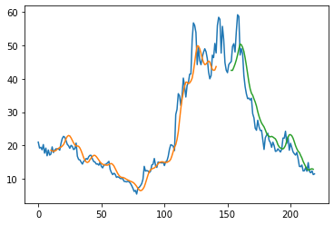

```python
### Plotting
# shift train predictions for plotting
look_back=10
trainPredictPlot = numpy.empty_like(df1)
trainPredictPlot[:, :] = np.nan
trainPredictPlot[look_back:len(train_predict)+look_back, :] = train_predict
# shift test predictions for plotting
testPredictPlot = numpy.empty_like(df1)
testPredictPlot[:, :] = numpy.nan
testPredictPlot[len(train_predict)+(look_back*2)+1:len(df1)-1, :] = test_predict
# plot baseline and predictions
plt.plot(scaler.inverse_transform(df1))
plt.plot(trainPredictPlot)
plt.plot(testPredictPlot)
plt.show()
```

```python
len(test_data)
```

```
77
```

```python
x_input=test_data[67:].reshape(1,-1)
x_input.shape
```

```
(1, 10)
```

```python
temp_input=list(x_input)
temp_input=temp_input[0].tolist()
```

```python
temp_input
```

```
[0.12897231237636705,
 0.13027318584414022,
 0.14867125345978913,
 0.1271139217081197,
 0.1756179181493759,
 0.1256272091735218,
 0.11875116370100655,
 0.12971566864366602,
 0.10871585409247078,
 0.11261847449579027]
```

```python
# demonstrate prediction for next 10 days
from numpy import array

lst_output=[]
n_steps=10
i=0
while(i<30):

    if(len(temp_input)>10):
        #print(temp_input)
        x_input=np.array(temp_input[1:])
        print("{} day input {}".format(i,x_input))
        x_input=x_input.reshape(1,-1)
        x_input = x_input.reshape((1, n_steps, 1))
        #print(x_input)
        yhat = model.predict(x_input, verbose=0)
        print("{} day output {}".format(i,yhat))
        temp_input.extend(yhat[0].tolist())
        temp_input=temp_input[1:]
        #print(temp_input)
        lst_output.extend(yhat.tolist())
        i=i+1
    else:
        x_input = x_input.reshape((1, n_steps,1))
        yhat = model.predict(x_input, verbose=0)
        print(yhat[0])
        temp_input.extend(yhat[0].tolist())
        print(len(temp_input))
        lst_output.extend(yhat.tolist())
        i=i+1


print(lst_output)
```

```
[0.12924254]
11
1 day input [0.13027319 0.14867125 0.12711392 0.17561792 0.12562721 0.11875116
 0.12971567 0.10871585 0.11261847 0.12924254]
1 day output [[0.12307656]]
2 day input [0.14867125 0.12711392 0.17561792 0.12562721 0.11875116 0.12971567
 0.10871585 0.11261847 0.12924254 0.12307656]
2 day output [[0.1189799]]
3 day input [0.12711392 0.17561792 0.12562721 0.11875116 0.12971567 0.10871585
 0.11261847 0.12924254 0.12307656 0.1189799 ]
3 day output [[0.11843123]]
4 day input [0.17561792 0.12562721 0.11875116 0.12971567 0.10871585 0.11261847
 0.12924254 0.12307656 0.1189799  0.11843123]
4 day output [[0.11718112]]
5 day input [0.12562721 0.11875116 0.12971567 0.10871585 0.11261847 0.12924254
 0.12307656 0.1189799  0.11843123 0.11718112]
5 day output [[0.12144017]]
6 day input [0.11875116 0.12971567 0.10871585 0.11261847 0.12924254 0.12307656
 0.1189799  0.11843123 0.11718112 0.12144017]
6 day output [[0.12179461]]
7 day input [0.12971567 0.10871585 0.11261847 0.12924254 0.12307656 0.1189799
 0.11843123 0.11718112 0.12144017 0.12179461]
7 day output [[0.12176053]]
8 day input [0.10871585 0.11261847 0.12924254 0.12307656 0.1189799  0.11843123
 0.11718112 0.12144017 0.12179461 0.12176053]
8 day output [[0.12300129]]
9 day input [0.11261847 0.12924254 0.12307656 0.1189799  0.11843123 0.11718112
 0.12144017 0.12179461 0.12176053 0.12300129]
9 day output [[0.12246092]]
10 day input [0.12924254 0.12307656 0.1189799  0.11843123 0.11718112 0.12144017
 0.12179461 0.12176053 0.12300129 0.12246092]
10 day output [[0.12228025]]
11 day input [0.12307656 0.1189799  0.11843123 0.11718112 0.12144017 0.12179461
 0.12176053 0.12300129 0.12246092 0.12228025]
11 day output [[0.12371974]]
12 day input [0.1189799  0.11843123 0.11718112 0.12144017 0.12179461 0.12176053
 0.12300129 0.12246092 0.12228025 0.12371974]
12 day output [[0.12467621]]
13 day input [0.11843123 0.11718112 0.12144017 0.12179461 0.12176053 0.12300129
 0.12246092 0.12228025 0.12371974 0.12467621]
```

[output cut: 35 more lines]

```
 0.12998937 0.13063499 0.13132454 0.13202097]
25 day output [[0.13271421]]
26 day input [0.12673214 0.1274236  0.12807262 0.12879547 0.12942661 0.12998937
 0.13063499 0.13132454 0.13202097 0.13271421]
26 day output [[0.13338773]]
27 day input [0.1274236  0.12807262 0.12879547 0.12942661 0.12998937 0.13063499
 0.13132454 0.13202097 0.13271421 0.13338773]
27 day output [[0.13407376]]
28 day input [0.12807262 0.12879547 0.12942661 0.12998937 0.13063499 0.13132454
 0.13202097 0.13271421 0.13338773 0.13407376]
28 day output [[0.13477388]]
29 day input [0.12879547 0.12942661 0.12998937 0.13063499 0.13132454 0.13202097
 0.13271421 0.13338773 0.13407376 0.13477388]
29 day output [[0.13548388]]
[[0.12924253940582275], [0.12307655811309814], [0.11897990107536316], [0.1184312254190445], [0.11718112230300903], [0.12144017219543457], [0.12179461121559143], [0.1217605322599411], [0.12300129234790802], [0.12246091663837433], [0.12228025496006012], [0.12371973693370819], [0.12467621266841888], [0…
```

```python
day_new=np.arange(1,101)
day_pred=np.arange(101,131)
```

```python
len(df1)
```

```
220
```

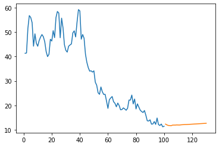

```python
plt.plot(day_new,scaler.inverse_transform(df1[120:]))
plt.plot(day_pred,scaler.inverse_transform(lst_output))
```

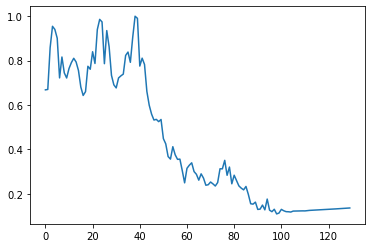

```python
df3=df1.tolist()
df3.extend(lst_output)
plt.plot(df3[120:])
```

```python
df3=scaler.inverse_transform(df3).tolist()
```

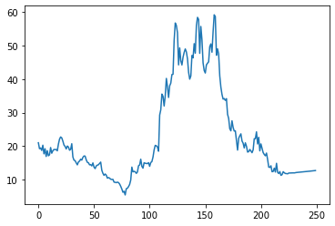

```python
plt.plot(df3)
```

CONCLUSION

The stock price of UPWK is expected to slightly increase or stay flat in the coming months